# Curve registration of functional data for approximate Bayesian computation

Anthony Ebert, Kerrie Mengersen, Fabrizio Ruggeri, Paul Wu

14 May 2019

# Abstract

Approximate Bayesian computation (Sisson, Fan, and Beaumont 2018) is a likelihood-free inference method which relies on comparing model realisations to observed data with informative distance measures. We obtain functional data that are not only measured with error on their observational axis, but are also subject to a random warping along their time axis. Conventional distances on functions, such as the the L$_2$ distance are not informative under these conditions. The Fisher-Rao metric, generalised by Srivastava et al. (2011) from the space of probability distributions to the space of functions, is an ideal objective function for aligning one function to another by warping the time axis. We examine the usefulness of this alignment with the distance for the purposes of approximate Bayesian computation with four examples: two toy examples, airport processing at an international airport and hydrological flow modelling. We find that while the Fisher-Rao metric works well as an objective function for alignment; however, once the functions are aligned, it is not necessarily the most informative distance for inference. This means that likelihood-free inference may require two distances, one for alignment and one for parameter inference.

# Introduction

In statistical problems of interest, what constitutes the sample space is sometimes a matter of perspective. For instance, in spectroscopy, if we measure the spectra of a series of samples, then we have a measurement for each combination of frequency and sample. The sample space could comprise the output range of the machine (a subset of the real line), or alternatively, the function space of the set of all possible spectra. Such data are termed functional data. Functional data analysis (FDA) proceeds with this latter approach and focuses on problems where this perspective provides useful insight (Hsing and Eubank 2015; Ramsay 2006).

Parameter inference with functional data is developed under many different names, including self-modelling (Kneip and Gasser 1988), functional-modelling (Ramsay 2006), and longitudinal data analysis (Laird and Ware 1982). However, these methods require evaluation of the likelihood function; in many statistical models of interest the likelihood function is either unavailable or intractable, but it is possible to draw realisations from the model conditional on parameter values. Approximate Bayesian computation (ABC) is a likelihood-free approach to parameter inference where proposed parameter values are accepted when a distance between model realisations and observed data is beneath some threshold (Sisson, Fan, and Beaumont 2018).

The distance is usually defined as a Euclidean distance between summary statistics of the observed data and the model realisation. For instance, Zhu et al. (2017) use wavelet compression to transform functional data into low-dimensional summary statistics, and Wood (2010) use estimators for parameters from an autoregressive model. Choosing the most effective summary statistics for a given problem is not trivial, and may be specific to the dataset in question (Nunes and Balding 2010). Recently, there has been work on using estimators for metrics on probability measures such as the Wasserstein distance (Bernton et al. 2019) and maximum mean discrepancy (MMD) (Gretton et al. 2012) and the Fisher-Rao metric (Srivastava, Jermyn, and Joshi 2007) to work with functional data. These estimators have been used within ABC samplers by Park, Jitkrittum, and Sejdinovic (2016) and Bernton et al. (2019).

In the following section, we provide some background to functional data analysis and introduce notation. In Section @ref(sec:ABC) we do the same for ABC. In this work, we extend ABC to functional data which displays both amplitude and phase variation. We demonstrate this with three examples: the first example is a toy example with a random distribution of peak shift position (Section @ref(sec:sG)), the second example is of passenger flow in an international airport terminal (Section @ref(sec:Airport)), and the third example is a model of hydrological modelling @ref(sec:Hydro)).

# Function data analysis

Functional data analysis (FDA) is a well established field of study (Ramsay 2006). Special-cases of functional datasets include longitudinal data and time series; however, the field of FDA is much broader (J.-L. Wang, Chiou, and Müller 2016). Functional random variables take values in a function space $\mathsf{f} \in \mathcal{F}$ (see Delaigle and Hall (2010)). In practice, $\mathsf{f}$ are smoothed empirical functions of noisy data $f$ observed on a countable subset of the domain. This is what we refer to as an empirical functional random variable (EFRV). An EFRV $f$ is itself a set of pairs $f_1, f_2, \cdots$ of the form $f_i = (t^f_{i},y^f_{i})$ representing sampling location $t^f_i$ and corresponding function output $y^f_{i}$. Therefore $f$ is of the form $\{ (t^f_{1},y^f_{1}), \cdots , (t^f_{j}, y^f_{j}), \cdots, (t^f_{n}, y^f_{n}) \}$. We append the superscript $f$ to keep track of which sampling points and functional outputs refer to which EFRV.

When analysing functional data, a statistic of interest is an estimate of the mean function $\mu(t) = \underset{\mathsf{f}\sim p}{\mathsf{E}}[\mathsf{f}](t)$. In the case of EFRVs with a shared set of sampling locations ($t^{f_1} = \cdots = t^{f_i} = \cdots$), this is usually estimated with $\hat{\mu}(t_j) = 1/n_i \sum_{i = 1}^{n_i} y^{f_i}_j$. In such cases, it is possible that the resulting function is not an element of $\mathcal{F}$ due to phase variation. For instance, if $\mathcal{F}$ is the set of Gaussian functions $\phi(t | \mu,\sigma)$ with $\mu \sim U(0, 5)$, $\sigma = 1$ then the mean function $\mu(t) = \frac{1}{n_i} \sum_{i=1}^{n_i} \phi(t|\mu_i, \sigma)$ is not Gaussian over $t$.

We assume the domain of $\mathcal{F}$ is $\mathbb{R}^{[0, T]}$, for some $T>0$. The idea of curve registration is to align elements of $\mathcal{F}$ with increasing and invertible automorphisms on the time axis called warping functions $\gamma: [0,T] \mapsto [0,T]$, such that elements of the set $\mathcal{G} := \{\mathsf{f} \circ \gamma | \mathsf{f} \in \mathcal{F} \}$ have aligned features according to some criteria. We adopt the elastic functions approach of Srivastava et al. (2011), who align $\mathsf{f}$ to another functional random variable $\mathsf{g}$ using the Fisher-Rao metric for functions:
$$\begin{align}
d_{\text{FR}}(\mathsf{f},\mathsf{g}) = \int [ q^{\mathsf{f}}(t) - q^{\mathsf{g}}(t) ]^2 \text{d} t, (\#eq:FR)
\end{align}$$
where $q^{\mathsf{f}}(t) = \text{sign}(\mathsf{f}^{\prime}(t)) \times \sqrt{|\mathsf{f}^{\prime}(t)|}$. Curve $\mathsf{f}$ is aligned to $\mathsf{g}$ by finding $\gamma$ which minimises $d_{\text{FR}}(\mathsf{f}\circ \gamma, \mathsf{g})$. One advantage of using $d_{\text{FR}}$ for curve registration is that:
$$\begin{align*}
d_{\text{FR}}(\mathsf{f}, \mathsf{g}) = d_{\text{FR}}(\mathsf{f}\circ \gamma, \mathsf{g}\circ \gamma),
\end{align*}$$
in other words, the Fisher-Rao metric is invariant to shared warpings. This implies that the discrepancy of amplitudes (amplitude distance) between $\mathsf{f}$ and $\mathsf{g}$, defined as
$$\begin{align*}
d_{\text{amp}}(\mathsf{f},\mathsf{g}) := \inf_{\gamma \in \Gamma} d_{\text{FR}}(\mathsf{f}\circ \gamma, \mathsf{g}),
\end{align*}$$
is symmetric (Srivastava et al. 2011). The R package fdasrvf (Tucker 2017), which we use, implements the approach of Srivastava et al. (2011). A cubic spline approximation approximates the smoothed first derivative $\mathsf{f}'(t)$.

For simplicity, we consider problems where the functional data comprise a single observed EFRV. We extend curve registration to the likelihood-free domain with approximate Bayesian computation (ABC). We proceed now with a brief background of ABC.

# Approximate Bayesian Computation

Suppose it is possible to draw samples from, but not evaluate a probability distribution $p(\cdot|\theta)$. Furthermore, we wish to perform inference on $\theta$. In such cases simulation-based approaches might be necessary; these are useful whenever $p(\cdot|\theta)$ represents a complicated simulator for generating realisations $x_{\theta} \sim p(\cdot|\theta)$.

The theoretical foundation of ABC rests on the fact that if we draw samples $\theta$ independently from the prior $\pi(\theta)$ and use each $\theta$ to generate a corresponding $x_{\theta}$ from $p(\cdot|\theta)$, then the set $\{\theta | x_{\theta} = x\}$ is sampled from $\pi(\theta|x)$. Such an approach would never work in practice as the proportion of $x_{\theta}$ samples equal to $x$ for models with continuous support is zero. For this reason, a distance $d$ between $x$ and $x_{\theta}$ is used within a decision rule to accept or reject $\theta$. In other words, we sample the set $\{\theta|d(x, x_{\theta}) \leq \epsilon \}$ for some fixed threshold $\epsilon > 0$. We should say dissimilarity, as defined by Jousselme and Maupin (2012), rather than distance since for ABC only a weaker notion than distance is needed, without the triangle inequality and where $x{=}y \implies d(x, y){=}0$ is true but the converse $d(x, y){=}0 \implies x{=}y$ is not true in general.

The FR metric for functions (Equation @ref(eq:FR)) is a distance, another distance which we use is the estimator for maximum mean discrepancy ($d_{\text{MMD}}$), developed by Gretton et al. (2007) as a non-parametric two-sample statistic for testing whether samples come from the same distribution. Park, Jitkrittum, and Sejdinovic (2016) use $d_{\text{MMD}}$ as a distance within an ABC algorithm. In our case, inputs to dissimilarities are functional data; which we emphasis by denoting them as $f$ and $g$. The definition of $d_{\text{MMD}}(f,g)$ is as follows:
$$\begin{align}
d_{\text{MMD}}(f,g) &= \frac{1}{m^2} \sum_{j=1}^m \sum_{j^{\prime} = 1}^{m} k(f_j, f_{j^{\prime}}) + \nonumber \\
&\quad \quad \frac{1}{n^2} \sum_{j=1}^n \sum_{j^{\prime} = 1 }^n k(g_j, g_{j^{\prime}}) \nonumber \nonumber \\
&\quad \quad - \frac{2}{mn} \sum_{j=1}^m \sum_{j^{\prime} = 1 }^n k(f_j, g_{j^{\prime}}), (\#eq:MMD)
\end{align}$$
where $m$ is the cardinality of $f$, $n$ is the cardinality of $g$ and $k$ is a kernel function. A common choice of kernel function is the Gaussian kernel, $k(f_j,g_{j^{\prime}}) = \exp \left[ -0.5 \sqrt{(t^f_j-t^g_{j^{\prime}})^T S^{-1} (y^f_j-y^g_{j^{\prime}})} \right]$, where $S$ is a fixed tuning covariance matrix. Gretton et al. (2012) showed that $d_{\text{MMD}}$ is equivalent to a kernel-smoothed L$_2$ metric between EFRVs. We can, therefore, use $\hat{\rho}_{\text{MMD}}$ as a distance on EFRVs rather than probability measures.

# Peak shift

## Method

The prior distributions for the parameters of interest are $\sigma_{\phi} \sim U(0, 3)$, $\sigma_{\text{C}} \sim U(0, 2)$, and $\sigma_{\epsilon} \sim U(0, 0.1)$. An example of a model realisation from this distribution is shown in Figure @ref(fig:sGExample).

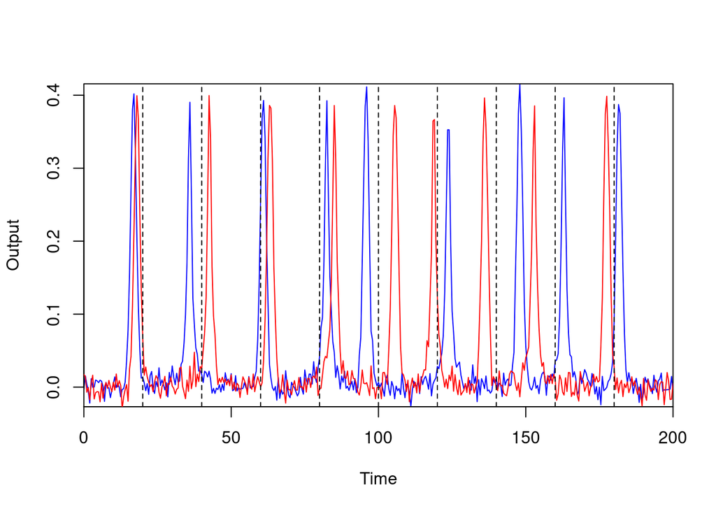

Example of model realisations from the peak shift model with $\sigma_b = 5, \sigma_{\phi} = 1$, and $\sigma_{\epsilon} = 0.01$. The dotted lines are the $\mu_u$ values. The distribution of peak shifts is controlled by $\sigma_b$, the peak widths are controlled by $\sigma_{\phi }$, and the noise is controlled by $\sigma_{\epsilon}$.

To test the effectiveness of registered loss functions in this situation, we compare all four combinations, i.e. MMD and FR with and without registration. We set the covariance matrix $S$ for MMD to be the $2 \times 2$ diagonal matrix with elements 9 and $1 \times 10^{-4}$, these values are related to the scale of the data (see Figure @ref(fig:sGExample)).

## Results

Density plots of posterior samples arising from the ABC sampler for the first toy problem with all four loss functions, registered and unregistered, are shown for the first toy problem (Figure @ref(fig:sGaussianPost)) and the second toy problem (Figure @ref(fig:skewPost)) show that registered loss functions outperform their unregistered counterparts. Interestingly the distance used for registration, FR, when used as the distance for ABC is sometimes outperformed by MMD which leads us to believe that the best distance for registration and the best distance for ABC do not always coincide, depending on the parameter of interest. The reason MMD outperforms FR for $\sigma_{\epsilon}$, in particular, is its penalty term. The first term in Equation penalises the concentration of $y^{f_{\theta}}$ such that the algorithm is lead to a higher value of $\sigma_{\epsilon}$ to match the noise in $y^{f}$. It is interesting that the same pattern of density plots is seen between the two examples, with the registered distances outperforming others for the scale parameters and the MMD distance (both registered and unregistered) outperforming the Fisher-Rao distance.

The relative merits of each distance are not our major concern here, we are interested in the effect of registration rather than the distance, so in further examples, we proceed only with MMD. We demonstrate now a more complex example with a dynamic queueing network model of an international airport terminal.

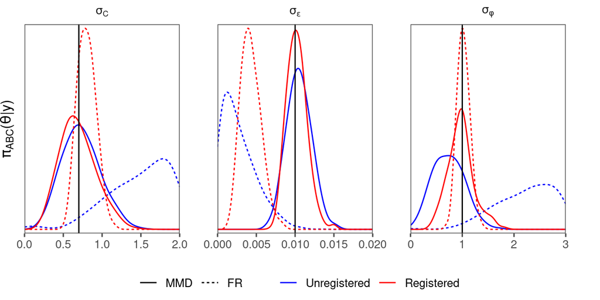

Gaussian/Cauchy peak shift example. Density plots of posterior samples arising from the replenishment ABC sampler. Distances shown include MMD (Maximum mean discrepancy) and FR (Fisher-Rao) in on both registered and unregistered data. Vertical black solid lines represent true values.

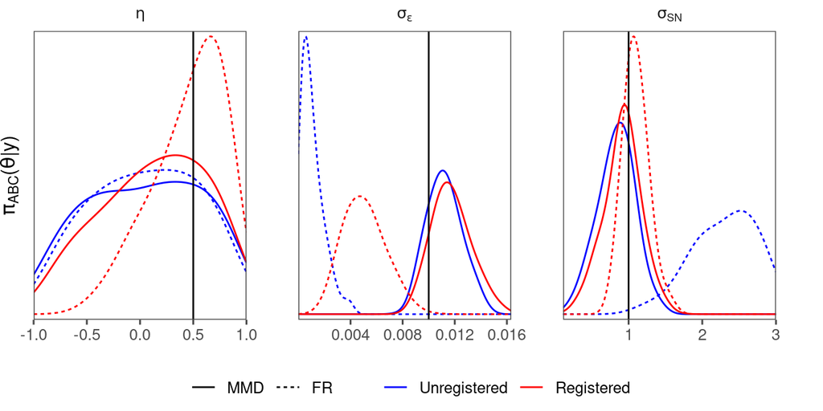

Skewed Gaussian peak shift example. Density plots of posterior samples arising from the replenishment ABC sampler. Distances shown include MMD (Maximum mean discrepancy) and FR (Fisher-Rao) in on both registered and unregistered data. Vertical black solid lines represent true values.

# Passenger processing at an international airport

Rising demand for air travel and enhanced security screening places pressure on existing airport infrastructure. Airport terminal infrastructure, for financial and geographical reasons, is difficult to upgrade at such a rate as to match this demand. With this in mind, operational planners at airports seek to optimise day-to-day operations. However, any optimisation framework requires a somewhat realistic model. To be a realistic model is will necessarily become complicated and this combined with the data collection scheme leads inevitably to intractable likelihoods. On the other hand, simulators are straight-forward to construct, although computationally demanding, this has prevented simulation-based approaches in the past.

A faster algorithm for queueing based algorithms called QDC (Ebert et al. 2020) was used by Ebert et al. (2021) to construct an ABC sampler for this problem. However, there were problems with misalignment as noted in the discussion of this paper. We consider a simplified (for the sake of exposition) version of the model and data as Ebert et al. (2021). The purpose of this model is to predict passenger flows through an airport terminal in response to particular flight schedules and staff rosters. The data comprise records of passenger numbers passing through certain check-points for each minute of the day. The flight schedule and staff rosters can be thought of as explanatory variables since they are known and affect the response variable (passenger flows) to some degree which we wish to infer.

## Method

We model the arrivals terminal of an international airport. For one day we have a list of flights $u$ along with their arrival gate $g_u$ and arrival time $a_u$. The walking distance $m_u$ from gate $g_u$ to immigration is also known. To model passenger flows, we simulate every passenger from every flight. The time at which passenger $v$ from flight $u$ deplanes is $a_{u,v}^{\text{dpl}} = a_{u} + t_{u,v}^{\text{dpl}} + b_u$ where $t_{u,v}^{\text{dpl}}$ is the time taken for the passenger to leave the aircraft and $b_u$ is an unobserved amount of time (0 - 20min) taken by the crew after the recorded arrival time to open the doors, letting passengers out. Note that in this example $b_u$ plays the same role as the peak shift example, that of a high dimensional latent variable shifting peaks independently.

Once passengers have deplaned, they walk to the immigration system and queue for processing. The times at which customers arrive to the queueing system are $a_{u,v}^{\text{imm}} = a_{u,v}^{\text{dpl}} + t_{u,v}^{\text{imm}}$ where $t_{u,v}^{\text{imm}}$ is the walking time to immigration from the arrival gate. The distribution of $t_{u,v}^{\text{imm}} | m_u$ is $\text{Gamma} ( \alpha, \beta/m_p )$. There are two parallel queueing systems, one for local and one for foreign passengers. The proportion of local passengers on each flight is known $l_u$, and encoded in the boolean variable $\text{nat}_{u,v} \sim \text{Bern}(l_u)$. Each queueing system proceeds at a different rate $\lambda_{\text{nat}}$ and has a different number of servers which are non-interchangeable, which is an accurate depiction of real systems including staff and automated systems working in parallel.

We require a queueing simulator to compute the times at which passengers leave their queueing system. A queueing simulator (QueueSim) is a function which (conditional on arrival times, service times and number of servers) deterministically computes times at which passengers leave their queueing system (departure times). First, we partition the arrival times $a_{u,v}^{\text{imm}}$ by $\text{nat}_{u,v}$; then we sample service times $s_{u,v} \sim \text{Exp}(\lambda_{\text{nat}_{u,v}})$. The number of servers $K_{\text{nat}}$ are known. The departure times from the queueing systems are $\mathbf{z}^{\text{imm}}_{\text{nat}} = \text{QueueSim}(\mathbf{a}^{\text{imm}}_{\text{nat}}, \mathbf{s}_{\text{nat}}, K_{\text{nat}})$, the variables are written in boldface to denote the full vectors partitioned by nationality since the movements of each passenger, once queueing begins, are no longer independent. We bin $\mathbf{a}_{\theta}^{\text{imm}}$ and $\mathbf{z}^{\text{imm}}$ by minute to construct $f^{a}_{\theta}$ and $f^{z}_{\theta}$ respectively. The synthetic data were also constructed in this manner so that we could know the true parameter values.

## Results

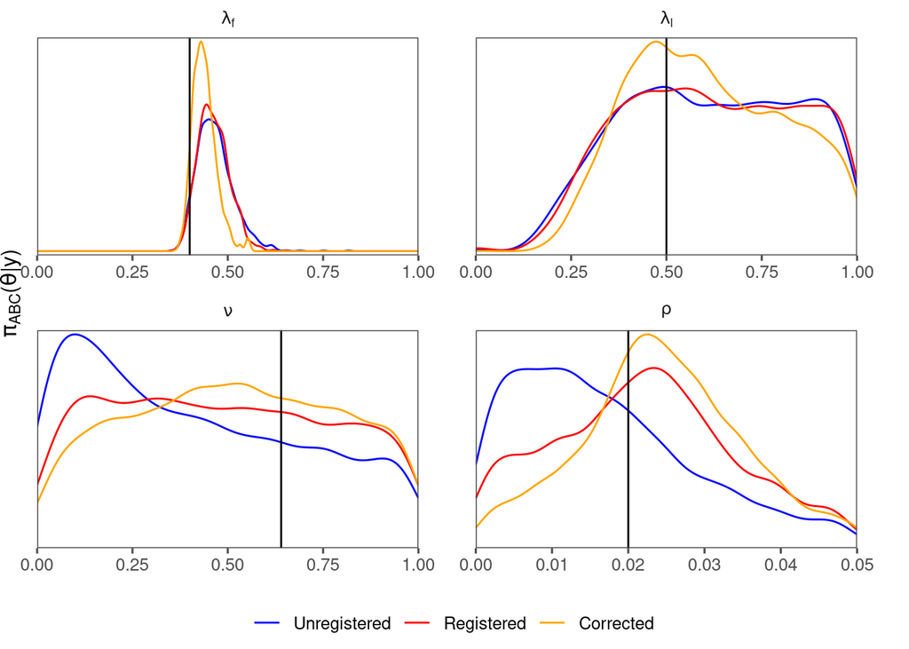

# Hydrological modelling

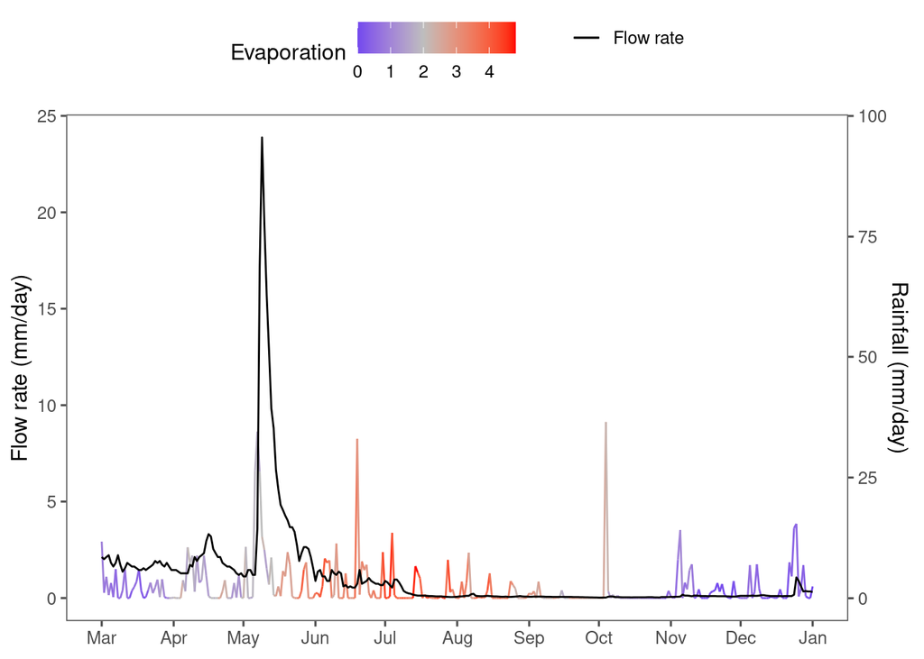

Synthetic hydrograph with associated rain and evaporation data from the airGR package

Parameter estimation proceeds with either expert opinion or automatic calibration. Automatic calibration is typically performed with a goodness-of-fit function such as sum of squared errors rather than a likelihood function. Parameter estimation for hydrological methods is an active area of research (Kavetski 2019). McInerney et al. (2018) argues that once parameters are estimated the parameter uncertainty itself contributes little to overall uncertainty compared to the residual error structure. We apply approximate Bayesian computation to this application for the first time and use the methodology of curve-registration.

## Results

Although this example includes peak shifting as is found in the previous two examples we see from density plots of posterior samples (Figure @ref(fig:HydroPost)) that the unregistered loss outperforms the unregistered loss. In those cases, there was a high dimensional latent variable $b_u$ affecting peak shift location, in this case, there is only one variable $\theta_4$. The process of registration is here unnecessary and adds noise to the loss function flattening the posterior densities. Since the peak positions are fixed, there is no advantage to curve registration.

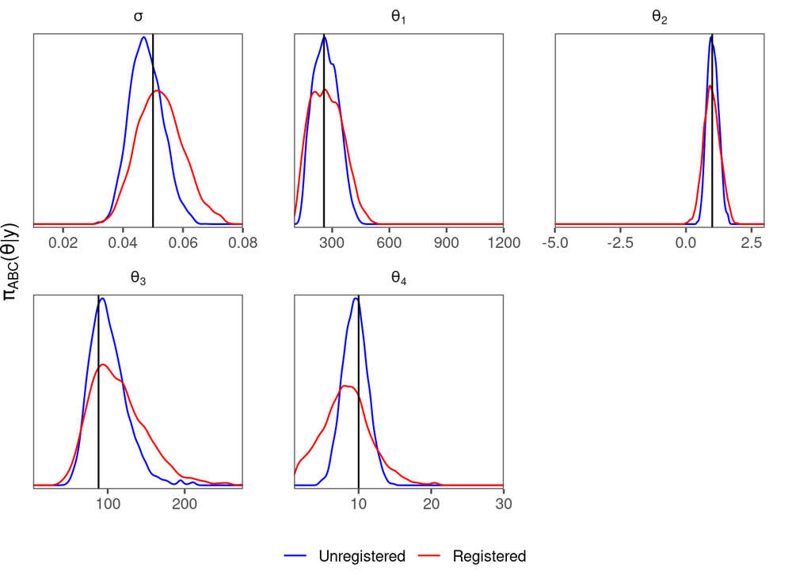

Density plots of posterior samples from the hydrological model using unregistered and registered loss function.

# Discussion

In this article, we applied curve registration techniques to the problem of misaligned functional data for likelihood-free inference for the first time. We used the Fisher-Rao metric for functional data (Srivastava et al. 2011) as an objective function to align model realisations to observed data through warping of the time axis, once aligned we compared the Fisher-Rao metric and maximum mean discrepancy as distances for the purposes of posterior inference within an ABC sampler.

# References

Albert, Carlo, Hans R. Künsch, and Andreas Scheidegger. 2015. “A Simulated Annealing Approach to Approximate Bayes Computations.” *Statistics and Computing* 25 (6): 1217–32.

Azzalini, Adelchi. 2005. “The Skew-Normal Distribution and Related Multivariate Families.” *Scandinavian Journal of Statistics* 32 (2): 159–88.

Azzalini, Adelchi, and Antonella Capitanio. 1999. “Statistical Applications of the Multivariate Skew Normal Distribution.” *Journal of the Royal Statistical Society: Series B (Statistical Methodology)* 61 (3): 579–602.

Bernton, Espen, Pierre E Jacob, Mathieu Gerber, and Christian P Robert. 2019. “Approximate Bayesian Computation with the Wasserstein Distance.” *Journal of the Royal Statistical Society: Series B (Statistical Methodology)* 81 (2): 235–69.

Cheng, Wen, Ian L Dryden, and Xianzheng Huang. 2016. “Bayesian Registration of Functions and Curves.” *Bayesian Analysis* 11 (2): 447–75.

Delaigle, Aurore, and Peter Hall. 2010. “Defining Probability Density for a Distribution of Random Functions.” *The Annals of Statistics* 38 (2): 1171–93.

Drovandi, Christopher C., and Anthony N. Pettitt. 2011. “Estimation of Parameters for Macroparasite Population Evolution Using Approximate Bayesian Computation.” *Biometrics* 67 (1): 225–33. http://onlinelibrary.wiley.com/doi/10.1111/j.1541-0420.2010.01410.x/full.

Ebert, Anthony, Ritabrata Dutta, Kerrie Mengersen, Antonietta Mira, Fabrizio Ruggeri, and Paul Wu. 2021. “Likelihood-Free Parameter Estimation for Dynamic Queueing Networks: Case Study of Passenger Flow in an International Airport Terminal.” *Journal of the Royal Statistical Society: Series C (Applied Statistics)*. https://doi.org/https://doi.org/10.1111/rssc.12487.

Ebert, Anthony, Paul Wu, Kerrie Mengersen, and Fabrizio Ruggeri. 2020. “Computationally Efficient Simulation of Queues: The r Package Queuecomputer.” *Journal of Statistical Software, Articles* 95 (5): 1–29. https://doi.org/10.18637/jss.v095.i05.

Gretton, Arthur, Karsten M. Borgwardt, Malte Rasch, Bernhard Schölkopf, and Alexander J. Smola. 2007. “A Kernel Method for the Two-Sample-Problem.” *Advances in Neural Information Processing Systems* 19: 513.

Gretton, Arthur, Karsten M Borgwardt, Malte J Rasch, Bernhard Schölkopf, and Alexander Smola. 2012. “A Kernel Two-Sample Test.” *Journal of Machine Learning Research* 13 (Mar): 723–73.

Hsing, Tailen, and Randall Eubank. 2015. *Theoretical Foundations of Functional Data Analysis, with an Introduction to Linear Operators*. John Wiley & Sons.

Joshi, Shantanu H, Eric Klassen, Anuj Srivastava, and Ian Jermyn. 2007. “A Novel Representation for Riemannian Analysis of Elastic Curves in $\mathbb{R}^n$.” In *Proceedings/CVPR, IEEE Computer Society Conference on Computer Vision and Pattern Recognition. IEEE Computer Society Conference on Computer Vision and Pattern Recognition*, 2007:1. 17-22 June 2007. NIH Public Access.

Jousselme, Anne-Laure, and Patrick Maupin. 2012. “Distances in Evidence Theory: Comprehensive Survey and Generalizations.” *International Journal of Approximate Reasoning* 53 (2): 118–45.

Kavetski, Dmitri. 2019. “Parameter Estimation and Predictive Uncertainty Quantification in Hydrological Modelling.” *Handbook of Hydrometeorological Ensemble Forecasting*, 481–522.

Kneip, Alois, and Theo Gasser. 1988. “Convergence and Consistency Results for Self-Modeling Nonlinear Regression.” *The Annals of Statistics* 16 (1): 82–112.

Kneip, Alois, and James O Ramsay. 2008. “Combining Registration and Fitting for Functional Models.” *Journal of the American Statistical Association* 103 (483): 1155–65.

Laird, Nan M, and James H Ware. 1982. “Random-Effects Models for Longitudinal Data.” *Biometrics* 38 (4): 963–74.

Maybank, Stephen J. 2008. “The Fisher-Rao Metric.” *Mathematics Today* 44 (6): 255–57.

McInerney, David, Mark Thyer, Dmitri Kavetski, Bree Bennett, Julien Lerat, Matthew Gibbs, and George Kuczera. 2018. “A Simplified Approach to Produce Probabilistic Hydrological Model Predictions.” *Environmental Modelling & Software* 109: 306–14.

Nunes, Matthew A, and David J Balding. 2010. “On Optimal Selection of Summary Statistics for Approximate Bayesian Computation.” *Statistical Applications in Genetics and Molecular Biology* 9 (1).

Padoy, N., T. Blum, S.-A. Ahmadi, H. Feussner, M.-O. Berger, and N. Navab. 2012. “Statistical Modeling and Recognition of Surgical Workflow.” *Medical Image Analysis* 16 (3): 632–41. https://doi.org/10.1016/j.media.2010.10.001.

Park, Mijung, Wittawat Jitkrittum, and Dino Sejdinovic. 2016. “K2-ABC: Approximate Bayesian Computation with Kernel Embeddings.” In *Artificial Intelligence and Statistics*, 398–407.

Perrin, Charles, Claude Michel, and Vazken Andréassian. 2003. “Improvement of a Parsimonious Model for Streamflow Simulation.” *Journal of Hydrology* 279 (1-4): 275–89.

Ramsay, James O. 2006. *Functional Data Analysis*. Springer.

Rao, C Radhakrishna. 1945. “Information and the Accuracy Attainable in the Estimation of Statistical Parameters.” *Bulletin of the Calcutta Mathematical Society* 37 (3): 81–91.

Sisson, Scott A, Yanan Fan, and Mark Beaumont. 2018. *Handbook of Approximate Bayesian Computation*. Chapman; Hall/CRC.

Srivastava, Anuj, Ian Jermyn, and Shantanu Joshi. 2007. “Riemannian Analysis of Probability Density Functions with Applications in Vision.” In *Computer Vision and Pattern Recognition, 2007. CVPR’07. IEEE Conference on*, 1–8. IEEE.

Srivastava, Anuj, Wei Wu, Sebastian Kurtek, Eric Klassen, and JS Marron. 2011. “Registration of Functional Data Using Fisher-Rao Metric.” *arXiv:1103.3817*.

Tavaré, Simon, David J. Balding, Robert C. Griffiths, and Peter Donnelly. 1997. “Inferring Coalescence Times from DNA Sequence Data.” *Genetics* 145 (2): 505–18. http://www.genetics.org/content/145/2/505.short.

Tucker, J. Derek. 2017. *fdasrvf: Elastic Functional Data Analysis*. https://CRAN.R-project.org/package=fdasrvf.

Wang, Jane-Ling, Jeng-Min Chiou, and Hans-Georg Müller. 2016. “Functional Data Analysis.” *Annual Review of Statistics and Its Application* 3: 257–95.

Wang, Kongming, and Theo Gasser. 1997. “Alignment of Curves by Dynamic Time Warping.” *The Annals of Statistics* 25 (3): 1251–76.

Wood, Simon N. 2010. “Statistical Inference for Noisy Nonlinear Ecological Dynamic Systems.” *Nature* 466 (7310): 1102–4. http://www.nature.com/nature/journal/v466/n7310/abs/nature09319.html.

Zhu, Hongxiao, Ruijin Lu, Chen Ming, Anupam K Gupta, and Rolf Müller. 2017. “Estimating Parameters in Complex Systems with Functional Outputs: A Wavelet-Based Approximate Bayesian Computation Approach.” In *New Advances in Statistics and Data Science*, 137–60. Springer.